# PumpIt

Jean Pierre Alvarez

11/28/2020

# Trabajo Final

El siguiente trabajo seguirá la siguiente metodología:

1. Descripción de los datos
2. Depuración y codificación, estandarización y creación de dummies
3. Estudio de selección de variables; selección primaria del mejor set bajo logística
4. Tuneo-optimización comentado de cada algoritmo con el mejor set de variables obtenido anteriormente
5. Ensamblado.
6. Conclusiones

## 1. Descripción de los datos

Origuen de los datos :

> [link](https://www.drivendata.org/competitions/7/pump-it-up-data-mining-the-water-table/data/)

Una breve descripción de las columnas que contiene el data set:

| Variable | Descripcion |
| --- | --- |
| date_recorded | Fecha que la fila fue ingresada |
| funder | Organización que fundó el punto de agua |
| gps_height | Altura del pozo |
| installer | Organización que instaló el punto de agua |
| longitude | GPS |
| latitude | GPS |
| wpt_name | Nombre del punto de agua (si es que hubiera uno) |
| basin | Localización Geografica (Cuenca) |
| subvillage | Localización Geografica (subaldea) |
| region | Localización Geografica ( region) |
| region_code | Localización Geografica (codigo region) |
| district_code | Localización Geografica (codigo districto) |
| lga | Localización Geografica |
| ward | Localización Geografica (Nombre del Barrio) |
| population | Población al rededor del pozo |
| public_meeting | True/False |
| recorded_by | Organizacion que ingreso esta información |
| scheme_management | Quien opera el punto de agua |
| scheme_name | Quien opera el punto de agua |
| permit | Si el punto de agua está permitido o no |
| construction_year | Año de construccion del punto de agua |
| extraction_type | Tipo de extracción de agua que el punto de agua utiliza |
| extraction_type_group | Grupo de extracción de agua que el punto de agua utiliza |
| extraction_type_class | Clase de extracción de agua que el punto de agua utiliza |
| management | Como se administra el punto de agua |
| management_group | Grupo como se administra el punto de agua |
| payment | Lo que costó el agúa |
| payment_type | Lo que costó el agúa |
| water_quality | Calidad del agua |
| quality_group | Grupo Calidad del agua |
| quantity | Cantidad de agua |
| quantity_group | Grupo de Cantidad de agua |
| source | Grupo Calidad del agua |
| quality_group | Fuente del agua |
| source_type | Tipo de la fuente de agua |
| source_class | Clase de la fuente de agua |
| quality_group | Grupo Calidad del agua |
| waterpoint_type | Tipo del punto de agua |
| waterpoint_type_group | Grupo tipo del punto de agua |

### 1.1 Cargamos los Datos

```r
# Por optimizacion usamos datatable
library(data.table)

# El siguiente archivo se utilizara para Train/Validation
dTrain       <- as.data.frame(fread("Assets/TrainingSetValues.csv", nThread = 2))
dTrain_label <- as.data.frame(fread("Assets/TrainingSetLabels.csv", nThread = 2))

# Y este archivo se usará para realizar las predicciones del concurso
dTest        <- fread( file = 'Assets/TestSetValues.csv', nThread = 2)
dTest_label  <- fread( file = 'Assets/Predicciones/SubmissionFormat_original.csv', nThread = 2)  #

dim(dTrain) # obs:59400    var: 40
```

```
## [1] 59400    40
```

```r
head(dTrain[1:5,1:5])
```

```
##      id amount_tsh date_recorded       funder gps_height
## 1 69572       6000    2011-03-14        Roman       1390
## 2  8776          0    2013-03-06      Grumeti       1399
## 3 34310         25    2013-02-25 Lottery Club        686
## 4 67743          0    2013-01-28       Unicef        263
## 5 19728          0    2011-07-13  Action In A          0
```

### 1.2 Exploración de datos

Proporción de valores de la variable objetivo:

| Tipo | % |
| --- | --- |
| functional | 54.30% |
| functional needs repair | 7.27% |
| non functional | 38.42% |

Con la función summary() ya se empiezan a observar algunos valores “raros” en los datos, como **gps_height** con un valor min. -90 y **amount_tsh** que su media es 317.7 pero tiene un max. 350000, de igual forma **population** tiene valor min. de 0 y max. 30500 de habitantes que viven al rededor del pozo y una media 179.9, lo cual puede haber outliers poco representativos.

```r
prop.table(table(dTrain_label$status_group)) * 100
# revisamos las clases asignadas a las variables
str(dTrain)
# revisión rapida de los datos
summary(dTrain)
```

Cuento el número de valores únicos diferentes para las numéricas:

```r
sapply(Filter(is.numeric, dTrain),function(x) length(unique(x)))
```

```
##                id        amount_tsh        gps_height         longitude
##             59400                98              2428             57516
##          latitude       num_private       region_code     district_code
##             57517                65                27                20
##        population construction_year
##              1049                55
```

Observamos que hay valores númericos que podrían ser considerados categoricas como **construction_year**, **region_code**, **district_code**, pero por el momento se quedarán como numéricas hasta que se realice más analisis

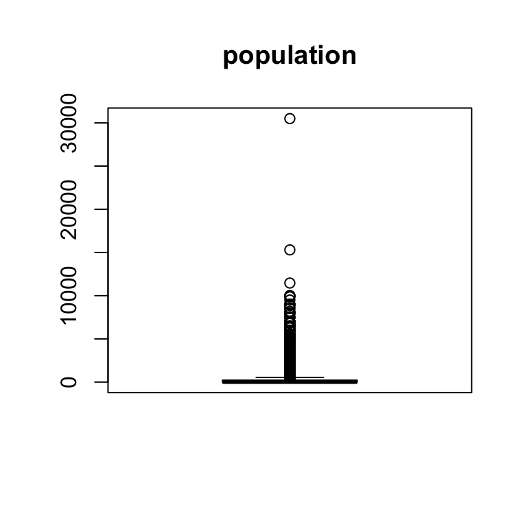

[figure not shown]

Sobre la variable **amount_tsh** cantidad de agua podría tener sentido si a altura del pozo también es proporcional. En resumen, los datos revelan la presencia de errores en tipos de variables, valores fuera de rango, missing no declarados, variables potencialmente nominales con categorías poco representadas

Continuamos con la inspeccion de datos con la librería inspectdf

```r
library(inspectdf)

# categorical plot
# se observan que hay muchas variables desproporcionales en el dataset
x <- inspect_cat(dTrain)
show_plot(x)

# correlations in numeric columns
# Observamos variables muy correlacionadas, como district_code-region_code y construction_year-gps_height
x <- inspect_cor(dTrain)
show_plot(x)

# feature imbalance bar plot
# muchas variables despropocionadas como: recorded_by, management_group, public_meeting, water_quality, quality_group
x <- inspect_imb(dTrain)
show_plot(x)

# memory usage barplot
# se observa que las variables wpt_name y subvillage son las mas pesadas con 2.85 MB y 1.57 MB respectivamente
x <- inspect_mem(dTrain)
show_plot(x)

# missingness barplot
x <- inspect_na(dTrain)
show_plot(x)

# histograms for numeric columns
# se observa que la variable gps_height esta muy desproporcionada en cantidad
# de igual forma construction_year hay muchos obs en el año 0, asi mismo population que hay varios puntos de agua con 0 habitantes
x <- inspect_num(dTrain)
show_plot(x)

# barplot of column types
x <- inspect_types(dTrain)
show_plot(x)
```

[output not shown]

Analizamos valores unicos de las variables cualitativas

```r
sapply(Filter(is.character, dTrain),function(x) length(unique(x)))
```

Las variables que coinciden por poco:

| Variable | Valores Unicos | Comentario |
| --- | --- | --- |
| subvillage | 19288 | Exceso de niveles |
| wpt_name | 37400 | Exceso de niveles |
| payment | 7 |  |
| payment_type | 7 | Posible var. duplicadas |
| recorded_by | 1 | Unico valor |
| water_quality | 8 |  |
| quality_group | 6 | Posible var. duplicadas |
| quantity | 5 |  |
| quantity_group | 5 | Posible var. duplicadas |
| source | 10 |  |
| source_type | 7 | Posible var. duplicadas |
| waterpoint_type | 7 |  |
| waterpoint_type_group | 7 | Posible var. duplicadas |

### 1.3 Limpieza de datos

Convertimos los character,logical a factor, los int a num e idate a date:

```r
dTrain[,sapply(dTrain, is.character)] <- lapply(dTrain[,sapply(dTrain, is.character)], as.factor)
dTrain[,sapply(dTrain, is.logical)]   <- lapply(dTrain[,sapply(dTrain,is.logical)], as.factor)
dTrain$date_recorded                  <- as.Date(dTrain$date_recorded)
dTrain[,sapply(dTrain, is.integer)]   <- lapply(dTrain[,sapply(dTrain,is.integer)], as.numeric)
```

Realizamos la distribución de las variables numericas:

```r
psych::describe(Filter(is.numeric, dTrain))
```

```
##                   vars     n     mean       sd   median  trimmed      mad
## id                   1 59400 37115.13 21453.13 37061.50 37108.41 27529.66
## amount_tsh           2 59400   317.65  2997.57     0.00    38.55     0.00
## gps_height           3 59400   668.30   693.12   369.00   604.09   547.08
## longitude            4 59400    34.08     6.57    34.91    35.06     3.01
## latitude             5 59400    -5.71     2.95    -5.02    -5.67     3.07
## num_private          6 59400     0.47    12.24     0.00     0.00     0.00
## region_code          7 59400    15.30    17.59    12.00    11.86     8.90
## district_code        8 59400     5.63     9.63     3.00     3.35     1.48
## population           9 59400   179.91   471.48    25.00    94.63    37.06
## construction_year   10 59400  1300.65   951.62  1986.00  1374.50    32.62
##                      min       max     range  skew kurtosis    se
## id                  0.00  74247.00  74247.00  0.00    -1.20 88.02
## amount_tsh          0.00 350000.00 350000.00 57.80  4902.97 12.30
## gps_height        -90.00   2770.00   2860.00  0.46    -1.29  2.84
## longitude           0.00     40.35     40.35 -4.19    19.18  0.03
## latitude          -11.65      0.00     11.65 -0.15    -1.06  0.01
## num_private         0.00   1776.00   1776.00 91.93 11135.98  0.05
## region_code         1.00     99.00     98.00  3.17    10.29  0.07
## district_code       0.00     80.00     80.00  3.96    16.21  0.04
## population          0.00  30500.00  30500.00 12.66   402.23  1.93
## construction_year   0.00   2013.00   2013.00 -0.63    -1.60  3.90
```

Se confirma presencia de outliers en **gps_height** y **population** ya que la media y la media presentan diferencias considerables, y aun queda entender porque existen valores negativos en gps_height, pero por falta de información se escoge no modificar esa variable.

Analizamos los posibles valores duplicados:

```r
library(dplyr)           # Manipulation
# se observa que region_code y region no tienen una relacion de 1 a 1 y una region puede tener distintos region_code
dTrain %>% group_by(region_code,region) %>% count() %>% arrange(desc(region))

#se observa que la relacion es de 1 a 1, por lo que son columnas duplicadas; se confirma missing no declarados
dTrain %>% group_by(payment, payment_type) %>% count() %>% arrange(desc(payment))

#  tal vez no sea necesario conservar water_quality porque son variables poco representativas por separado
dTrain %>% group_by(water_quality,quality_group) %>% count() %>% arrange(desc(water_quality))

# al ser identicas, eliminamos quantity_group
dTrain %>% group_by(quantity,quantity_group) %>% count() %>% arrange(desc(quantity))

# son muy parecidas, y podriamos quedarnos con source_type para una segunda iteracion
dTrain %>% group_by(source,source_type) %>% count() %>% arrange(desc(source))

# nos quedamos con waterpoint_type excluir waterpoint_type_group
dTrain %>% group_by(waterpoint_type,waterpoint_type_group) %>% count() %>% arrange(desc(waterpoint_type))
table(dTrain$waterpoint_type_group, dTrain_label$status_group)

#se puede limpiar esta variable ya que estan mal escritos algunos nombres o hay espacios demás
#dTrain %>% group_by(fe_installer) %>% count() %>% arrange() # 2146   transformando se obtiene 1882 valoes unicos
#trim <- function (x) gsub("^\\s+|\\s+$", "", x)
#dataT$fe_installer <- toupper(str_replace_all(string=dataT$installer, pattern=" ", repl="") )

dTrain %>% group_by(quantity) %>% count() %>% arrange(desc(n))
table(dTrain$quantity, dTrain_label$status_group)

#dTrain %>% group_by(funder,installer) %>% count() %>% arrange(desc(funder))
table(dTrain$population, dTrain_label$status_group)
#  p      functional     functional needs repair       non functional
#  0          11274                    1775           8332
```

Hasta el momento lo que se ha encontrado en la data:

| Variable | Comentario |
| --- | --- |
| funder | Palabras mal escritas, espacios en blanco, missing no declarados y niveles de frecuencia bajos en algunos |
| funder&Installer | suelen coincidir la relacion 1 a 1 excepto por algunos valores |
| scheme_name | presenta espacios en blanco, NA’s 28166 47.4% |
| population | Tiene valores 0, lo cual es raro ver puntos de agua y no una población que viva al rededor en tanzania |
| permit y public_meeting | Tiene NA’s |
| payment y payment_type | Valores duplicados |
| water_quality y quality_group | Valores duplicados excepto por algunos casos |
| quantity y quantity_group | Valores duplicados |
| source y source_type | Valores muy parecidos |
| population | Valores 0, y la gran mayoria tiene puntos de agua funcionales lo cual confirma que son missing no declarados |
| subvillage | presenta espacios en blanco, NA’s 371 0.6% |

```r
# Revisamos la proporcion de missings de cada variable
head(questionr::freq(dTrain$scheme_management, sort = "dec") )
```

```
##                     n    % val%
## VWC             36793 61.9 61.9
## WUG              5206  8.8  8.8
##                  3877  6.5  6.5
## Water authority  3153  5.3  5.3
## WUA              2883  4.9  4.9
## Water Board      2748  4.6  4.6
```

Adicional La mayoria de puntos de agua se encuentran funcionales y tan solo un 7.3% necesitan reparacion, el 38.4% no se encuentran operativos

- functional - 32259 - 54.3%
- functional needs repair - 4317 - 7.3%
- non functional - 22824 - 38.4%

## 2 Depuración y codificación, estandarización y creación de dummies

### 2.1 Tratamiento de missings no declarados

Recodificamos los missings, para una segunda iteración es podria considerar convertir a NA’s las variables que tienen “unknown” en sus niveles

```r
library(questionr)
# Creamos una nueva variable para tratar la informacion
data <- dTrain
data$scheme_management<-recode.na(data$scheme_management,'')
data$scheme_management<-recode.na(data$scheme_management,'None')
data$subvillage       <-recode.na(data$subvillage,'')
data$funder           <-recode.na(data$funder,0)
data$funder           <-recode.na(data$funder,'0')
data$installer        <-recode.na(data$installer,0)
data$installer        <-recode.na(data$installer,'0')
data$construction_year<-recode.na(data$construction_year,0)
data$construction_year<-recode.na(data$construction_year,'0')

#revisamos que existen 20709 que son NA's y l resto esta entre 1000-2000 obs
data %>% group_by(construction_year) %>% count() %>% arrange(desc(n))
data %>% group_by(population) %>% count() %>% arrange(desc(n))
```